# act_report

## Report: act_report for WeRateDogs

### Insights

A variety of questions were posed and answered during analysis.

- what source was mostly used to tweet?
- what was the average engagements on tweets made by the account?
- how many dog breeds were rated and which were the most popular?
- which dog stage was the most popular?
- which dog stage had the most engagements?
- what was the average engagement for each dog stage?
- what was the average prediction accuracy of image?
- which dog had the most likes?
- which dog had the highest rating?
- most common dog name?
- what is the correlation between likes and retweets?

#### What source was mostly used to tweet?

Approximately 98% of all tweets by the WeRateDogs account were made with an iphone and this numbered around 1635 tweets. Twitter for web and tweetdeck make up the remaining 2%.

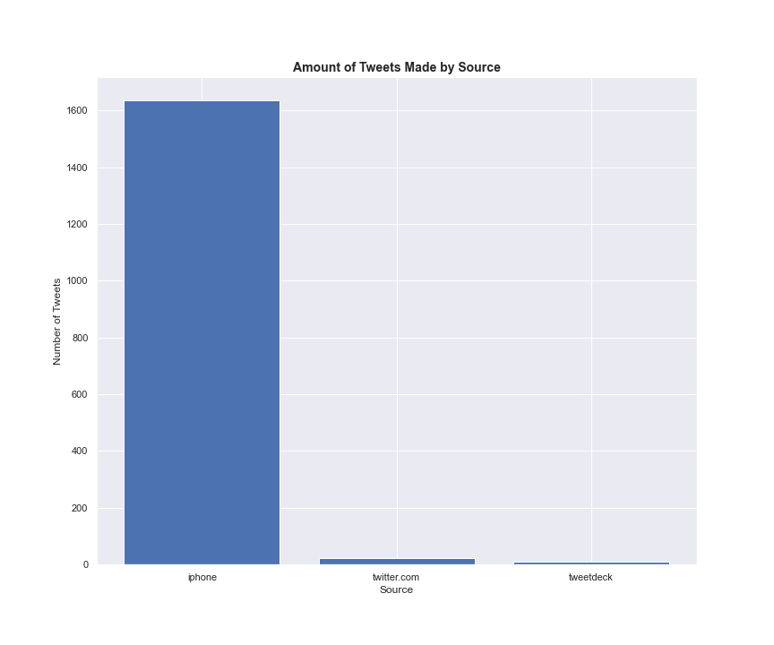

#### What was the average engagements on tweets made by the account?

Each dog rating tweet by the account had 9288 likes and 2834 retweets on average.

#### How many dog breeds were rated and which were the most popular?

There were 113 dog breeds across all rating tweets with golden retrievers and labrador retrievers featuring way more than other breeds.

#### Which dog stage was the most popular?

Amongst the 4 dog stages tweeted, dogs in the pupper stage got tweeted and rated regularly. They were followed by gogs in doggo, puppo stages respectively. just 7 floofer dogs were rated.

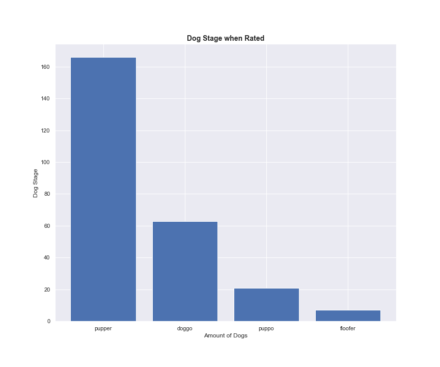

#### Which dog stage had the most engagements?

Doggo rating tweets were retweeted more than tweets for any other dog stage and pupper tweets had most likes. Although when combined, puppers had more engagements than any other breed.

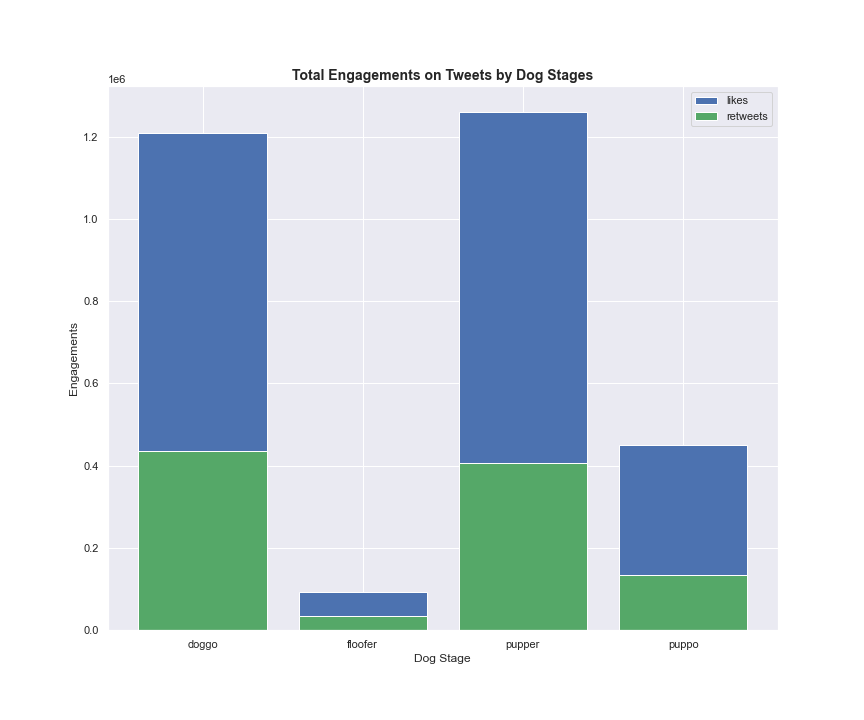

#### What was the average engagement for each dog stage

The average doggo tweet had more retweets than any other type. Despite having a larger volume of tweets, pupper tweets on an average had the least engagements. Puppo rating tweets had more combined engagements(likes and retweets) per tweet than other rating tweets.

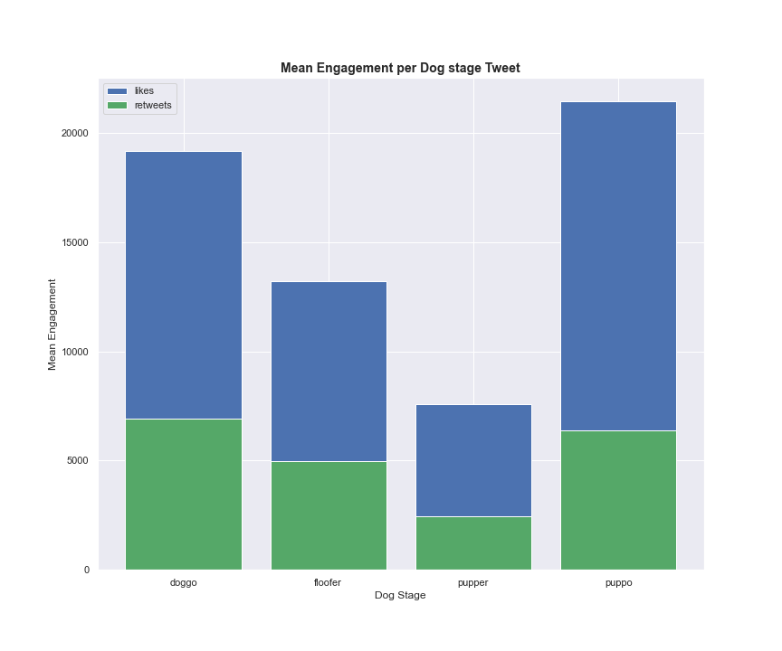

#### What was the average algorithm confidence on image predicted?

The breed predictions were made with an average algorithm confidence of 55.2%.

#### Which dog had the most likes?

A lakeland terrier with a rating of 13/10 was the most liked dog with approximately 133k likes. It seemingly looked like it was on a sort of march/protest.

#### Which dog had the highest rating?

The highest rating was 165 which was unusual given the mean rating was 13. On further inspection, it was found that this rating was given to a group of dogs and not just one.

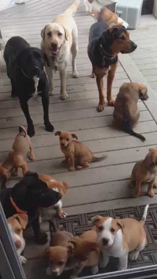

#### The most common dog name?

Three names were tied for this with 10 dogs each named Charlie, Lucy and Cooper.

#### What is the correlation between likes and retweets?

There was actually a very strong positive correlation between the amount of likes a rating tweet got and the amount of retweets on it.

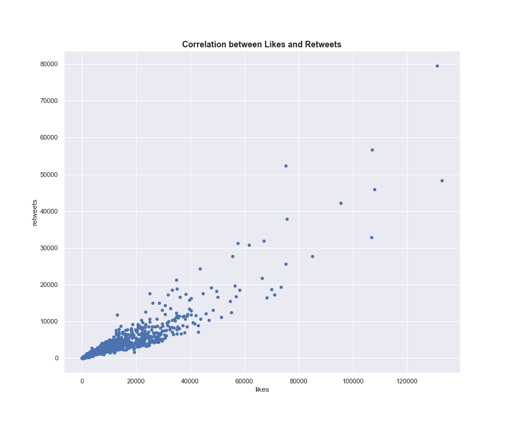